# Notebook

## Exercise 2: Subsetting the data

- Subset the data by creating new dataframe only with `["rating", 'isbn', 'author_url', 'year', 'genre_urls', 'name']`

```python
# your code here
# use many cells if you like to structure your code well
df.loc[:,['rating', 'isbn', 'author_url', 'year', 'genre_urls', 'name']]

#Other possible answers:
#subset = db[['rating', 'isbn', 'author_url', 'year', 'genre_urls', 'name']]
#subset

#df_new = df.drop(columns=["review_count", "booktype", "dir", "rating_count"])
#df_new
```

|  | rating | isbn | author_url | year | genre_urls | name |
| --- | --- | --- | --- | --- | --- | --- |
| 0 | 4.40 | 0439023483 | https://www.goodreads.com/author/show/153394.S... | 2008.0 | /genres/young-adult\|/genres/science-fiction\|/g... | The Hunger Games (The Hunger Games, #1) |
| 1 | 4.41 | 0439358078 | https://www.goodreads.com/author/show/1077326.... | 2003.0 | /genres/fantasy\|/genres/young-adult\|/genres/fi... | Harry Potter and the Order of the Phoenix (Har... |
| 2 | 3.56 | 0316015849 | https://www.goodreads.com/author/show/941441.S... | 2005.0 | /genres/young-adult\|/genres/fantasy\|/genres/ro... | Twilight (Twilight, #1) |
| 3 | 4.23 | 0061120081 | https://www.goodreads.com/author/show/1825.Har... | 1960.0 | /genres/classics\|/genres/fiction\|/genres/histo... | To Kill a Mockingbird |
| 4 | 4.23 | 0679783261 | https://www.goodreads.com/author/show/1265.Jan... | 1813.0 | /genres/classics\|/genres/fiction\|/genres/roman... | Pride and Prejudice |
| ... | ... | ... | ... | ... | ... | ... |
| 5995 | 4.17 | 0767913736 | https://www.goodreads.com/author/show/44565.Ca... | 2005.0 | /genres/history\|/genres/non-fiction\|/genres/bi... | The River of Doubt |
| 5996 | 3.99 | 1416909427 | https://www.goodreads.com/author/show/151371.J... | 2006.0 | /genres/young-adult\|/genres/realistic-fiction\|... | Shug |
| 5997 | 3.78 | 1620612321 | https://www.goodreads.com/author/show/5761314.... | 2012.0 | /genres/contemporary\|/genres/romance\|/genres/y... | Flawed |
| 5998 | 3.91 | NaN | https://www.goodreads.com/author/show/1201952.... | 2006.0 | /genres/religion\|/genres/islam\|/genres/religio... | Ø£Ø³Ø¹Ø¯ Ø§Ù Ø±Ø£Ø© ÙÙ Ø§ÙØ¹Ø§ÙÙ |
| 5999 | 4.35 | 0786929081 | https://www.goodreads.com/author/show/1023510.... | 2001.0 | /genres/fiction\|/genres/fantasy\|/genres/magic\|... | Legacy of the Drow Collector's Edition (Legacy... |

6000 rows × 6 columns

## Exercise 3: Manage Missing Data

We’ve got a number of ways in general of dealing with missing data. These involve

1. Dropping off cases (or rows) in the data with any missing variables
2. Excluding variables in the data with any missing data
3. Selectively choosing indicators with only a limited amount of missing data
4. Replacing missing variables with averages, or other representative values
5. Creating a separate model to predict missing data
- Count the missing values in each column
- Manage the missing values (delete or replace values or leave them as they are) and briefly explain your choice for each column

```python
# your code here
# use many cells if you like to structure your code well
good_reads2 = df

df.dtypes
```

```
rating          float64
review_count    float64
isbn             object
booktype         object
author_url       object
year            float64
genre_urls       object
dir              object
rating_count    float64
name             object
dtype: object
```

```python
print(np.sum([good_reads2.rating.isnull()]))
print(np.sum([good_reads2.review_count.isnull()]))
print(np.sum([good_reads2.isbn.isnull()]))
print(np.sum([good_reads2.booktype.isnull()]))
print(np.sum([good_reads2.author_url.isnull()]))
print(np.sum([good_reads2.year.isnull()]))
print(np.sum([good_reads2.genre_urls.isnull()]))
print(np.sum([good_reads2.dir.isnull()]))
print(np.sum([good_reads2.rating_count.isnull()]))
print(np.sum([good_reads2.name.isnull()]))
```

```
2
2
477
2
2
7
62
0
2
2
```

```python
#check the missing rating

df[df.rating.isnull()]

#these two are also missing the values for review_count, booktype, author_url, rating_count, name so we removed the two.
```

|  | rating | review_count | isbn | booktype | author_url | year | genre_urls | dir | rating_count | name |
| --- | --- | --- | --- | --- | --- | --- | --- | --- | --- | --- |
| 3643 | NaN | NaN | NaN | NaN | NaN | NaN | NaN | dir37/9658936-harry-potter.html | NaN | NaN |
| 5282 | NaN | NaN | NaN | NaN | NaN | NaN | NaN | dir53/113138.The_Winner.html | NaN | NaN |

```python
df =df[df.rating.notnull()]
```

```python
df.shape
```

```
(5998, 10)
```

```python
df.fillna('Unknown', inplace=True)

#Find representative values is not easily done with this data set, because it is very specific data. We chose to put unknown for the missing data. Because if you have the book title and author you do not need the isbn.
```

## Exercise 4: Shape the data

- Parse the `author_url` to create new column named `author`
- Sort the data by putting higher rates go first. If there are overlapping rates, try to put earlier years go first.
- **(Stretch Goal)** Examine how many books were published at each year and find lowest, highest rate of each year.

```python
# your code here
# use many cells if you like to structure your code well
df['year'] = pd.to_numeric(df['year'], errors='coerce')
#skip values 'Unknows' to make column numeric

#change data types from strings to integers/float
df.rating=df.rating.astype(int)
df.rating_count=df.rating_count.astype(int)
df.review_count=df.review_count.astype(int)
#db.year=db.year.astype(int, errors='coerce')
#how do I change the datatype from float to int when there are values 'Unknown'
df.dtypes
```

```
rating            int64
review_count      int64
isbn             object
booktype         object
author_url       object
year            float64
genre_urls       object
dir              object
rating_count      int64
name             object
dtype: object
```

```python
test_string = df.author_url[0]
test_string

#split author name from url
test_string.split('/')[-1].split('.')[1:][0]
#how this works ('https://www.goodreads.com/author/show/153394.Suzanne_Collins' is the url): I first split at the last '/', I indicate the last with [-1]
#then I split again starting at the dot where I use [1:] which extracts all elements in the list starting form index 1 onwards
#[0] grabs the first element of the list

# A function that accepts an author url and returns the author's name
def get_author(url):

    name = url.split('/')[-1].split('.')[1:][0]

    return name

#Apply the get_author function to the 'author_url' column using '.map'
#and add a new column 'author' to store the names
df['author'] = df.author_url.map(get_author)
df.author[0:5]
```

```
0    Suzanne_Collins
1        J_K_Rowling
2    Stephenie_Meyer
3         Harper_Lee
4        Jane_Austen
Name: author, dtype: object
```

```python
 #sort rating with higher rates first
rating_sorted = df.sort_values(by=['rating', 'year'], ascending=False)
rating_sorted
```

|  | rating | review_count | isbn | booktype | author_url | year | genre_urls | dir | rating_count | name | author |
| --- | --- | --- | --- | --- | --- | --- | --- | --- | --- | --- | --- |
| 1718 | 5 | 28 | Unknown | good_reads:book | https://www.goodreads.com/author/show/6467808.... | 2014.0 | /genres/poetry\|/genres/childrens | dir18/22204746-an-elephant-is-on-my-house.html | 64 | An Elephant Is On My House | Othen_Donald_Dale_Cummings |
| 5564 | 5 | 9 | Unknown | good_reads:book | https://www.goodreads.com/author/show/7738947.... | 2014.0 | /genres/romance\|/genres/new-adult | dir56/21902777-untainted.html | 14 | Untainted (Photographer Trilogy, #3) | Sarah_Robinson |
| 2145 | 5 | 3 | 1300589469 | good_reads:book | https://www.goodreads.com/author/show/6906561.... | 2012.0 | Unknown | dir22/17287259-a-book-about-absolutely-nothing... | 63 | A Book About Absolutely Nothing. | I_M_Nobody |
| 2903 | 5 | 0 | 0983002282 | good_reads:book | https://www.goodreads.com/author/show/6589034.... | 2012.0 | Unknown | dir30/17608096-obscured-darkness.html | 8 | Obscured Darkness (Family Secrets #2) | Rebekah_McClew |
| 4473 | 5 | 0 | Unknown | good_reads:book | https://www.goodreads.com/author/show/6896621.... | 2012.0 | Unknown | dir45/17259227-patience-s-love.html | 7 | Patience's Love | Ronda_Paige |
| ... | ... | ... | ... | ... | ... | ... | ... | ... | ... | ... | ... |
| 5572 | 3 | 35 | 8423336603 | good_reads:book | https://www.goodreads.com/author/show/285658.E... | NaN | /genres/fiction | dir56/890680._rase_una_vez_el_amor_pero_tuve_q... | 403 | Ãrase una vez el amor pero tuve que matarlo. ... | Efraim_Medina_Reyes |
| 2609 | 2 | 8 | Unknown | good_reads:book | https://www.goodreads.com/author/show/7707820.... | 2013.0 | /genres/romance\|/genres/realistic-fiction\|/gen... | dir27/19546932-how-to-be-a-perfect-girl.html | 31 | How To Be A Perfect Girl | Mary_Williams |
| 3738 | 2 | 368 | 0983650322 | good_reads:book | https://www.goodreads.com/author/show/9414.Vic... | 2011.0 | /genres/young-adult\|/genres/science-fiction\|/g... | dir38/12393909-revealing-eden.html | 688 | Revealing Eden (Save the Pearls, #1) | Victoria_Foyt |
| 5979 | 2 | 800 | 0060988649 | good_reads:book | https://www.goodreads.com/author/show/7025.Gre... | 2001.0 | /genres/fantasy\|/genres/fiction\|/genres/myster... | dir60/24929.Lost.html | 11128 | Lost | Gregory_Maguire |
| 5844 | 2 | 1399 | 0395083621 | good_reads:book | https://www.goodreads.com/author/show/30691.Ad... | 1925.0 | /genres/history\|/genres/non-fiction\|/genres/bi... | dir59/54270.Mein_Kampf.html | 12417 | Mein Kampf | Adolf_Hitler |

5998 rows × 11 columns

```python
#group data based on all columns of year?
#if more than one row exists with a certain value these are grouped
dfgb_year = df.groupby('year')
type(dfgb_year)

dfgb_year.count()
```

| year | rating | review_count | isbn | booktype | author_url | genre_urls | dir | rating_count | name | author |
| --- | --- | --- | --- | --- | --- | --- | --- | --- | --- | --- |
| -1500.0 | 1 | 1 | 1 | 1 | 1 | 1 | 1 | 1 | 1 | 1 |
| -800.0 | 2 | 2 | 2 | 2 | 2 | 2 | 2 | 2 | 2 | 2 |
| -560.0 | 1 | 1 | 1 | 1 | 1 | 1 | 1 | 1 | 1 | 1 |
| -512.0 | 1 | 1 | 1 | 1 | 1 | 1 | 1 | 1 | 1 | 1 |
| -500.0 | 1 | 1 | 1 | 1 | 1 | 1 | 1 | 1 | 1 | 1 |
| ... | ... | ... | ... | ... | ... | ... | ... | ... | ... | ... |
| 2010.0 | 317 | 317 | 317 | 317 | 317 | 317 | 317 | 317 | 317 | 317 |
| 2011.0 | 374 | 374 | 374 | 374 | 374 | 374 | 374 | 374 | 374 | 374 |
| 2012.0 | 355 | 355 | 355 | 355 | 355 | 355 | 355 | 355 | 355 | 355 |
| 2013.0 | 276 | 276 | 276 | 276 | 276 | 276 | 276 | 276 | 276 | 276 |
| 2014.0 | 87 | 87 | 87 | 87 | 87 | 87 | 87 | 87 | 87 | 87 |

293 rows × 10 columns

```python
#separate maximum value for category 'year' where the value is 'rating'
#max_values = db.groupby('year')['rating'].max()
#print("Maximum Values:\n", max_values)

#you can combine the min and max values in one function
extreme_values = df.groupby('year')['rating'].agg(['max', 'min'])
print("\nMax and Min Values:\n", extreme_values)
```

```
Max and Min Values:
          max  min
year
-1500.0    3    3
-800.0     4    3
-560.0     4    4
-512.0     3    3
-500.0     4    4
...      ...  ...
 2010.0    4    3
 2011.0    5    2
 2012.0    5    3
 2013.0    4    2
 2014.0    5    3

[293 rows x 2 columns]
```

## Exercise 5: Saving the results

- Save the cleaned dataframe as 'hw-03-cleaned.csv' in data folder

```python
df.to_csv('data\hw-03-cleaned.csv', index=False)
```

## Exercise 6: Investigate the relationship between the number of reviews and the average rating for books in the dataset cleaned-goodreads.csv procided.

- Calculate the correlation coefficient. Give me a short definition of this coefficient
- Create a scatter plot showing the relationship between these two features.
- Based on the plot and the correlation, provide a brief interpretation of the relationship.

### Python Tools: Use pandas and numpy for correlation, and matplotlib or seaborn for the scatter plot.

```
Correlation coefficient between rating and review count: -0.03789637257875289
```

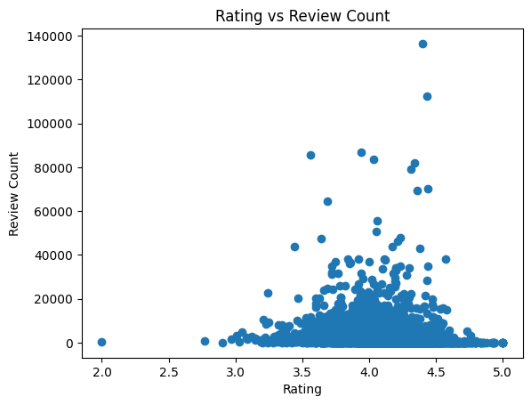

```python
# Relation between number of reviews and rating

df = pd.read_csv("/Users/juliavanraamsdonk/Documents/Studie/MADE/Year 1/Data 1/lab-02/data/cleaned-goodreads.csv")

# Calculate correlation coefficient
correlation = df['rating'].corr(df['review_count'])

print(f"Correlation coefficient between rating and review count: {correlation}")

# A correlation coeffecient of -0.038 indicates a very weak negative correlation between rating and review count. This means that (based on this data) having more reviews means a slightly lower rating, but the correlation is so weak that it is not significant.

# Scatter plot of rating and review count


plt.scatter(df['rating'], df['review_count'])
plt.xlabel('Rating')
plt.ylabel('Review Count')
plt.title('Rating vs Review Count')
plt.show()

# The scatter plot shows that there is no clear relationship between rating and review count. They seem bunched up around a low review count (0 - 20000) and around a rating of 3.5 - 4.5, but no trend can be seen. This confirms the weak correlation coefficient.
```

## Exercise 7: Calculate the following descriptive statistics for the numerical features (e.g., number of reviews, average rating, etc.):

- Mean
- Median
- Standard Deviation
- Range
- Create a histogram or box plot for at least one of the numerical features, highlighting any skewness or outliers.

### Python Tools: Use pandas for data manipulation and matplotlib or seaborn for visualization.

```
Feature: rating
Mean: 4.041997330218589
Median: 4.05
Standard deviation: 0.2605090887217234
Range: 3.0

Feature: review_count
Mean: 2374.3312197563823
Median: 936.0
Standard deviation: 5493.093328445107
Range: 136455

Feature: year
Mean: 1969.0850992824962
Median: 2002.0
Standard deviation: 185.38316893844993
Range: 3514

Feature: rating_count
Mean: 51183.89587852495
Median: 18072.0
Standard deviation: 137649.3356325423
Range: 2958969
```

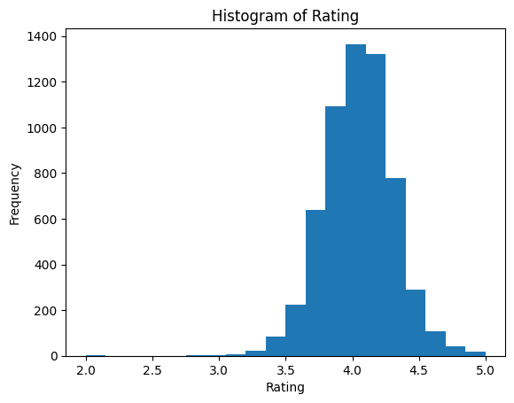

```
Books with rating of 2.0:
```

|  | author | name | rating |
| --- | --- | --- | --- |
| 3735 | Victoria_Foyt | Revealing Eden (Save the Pearls, #1) | 2.0 |

```python
# For the numerical features we calculate: mean, median, standard deviation, range. We also create a histogram for one feature.

numerical_features = ['rating', 'review_count', 'year', 'rating_count'] # Skipped 'isbn' because it is essentially a name / ID.

for feature in numerical_features:
    print(f"Feature: {feature}")
    print(f"Mean: {df[feature].mean()}")
    print(f"Median: {df[feature].median()}")
    print(f"Standard deviation: {df[feature].std()}")
    print(f"Range: {df[feature].max() - df[feature].min()}")
    print()

# Histogram for 'rating'
plt.hist(df['rating'], bins=20)
plt.xlabel('Rating')
plt.ylabel('Frequency')
plt.title('Histogram of Rating')
plt.show()

# Note the small bump at the 2.0 rating. A single book has a rating of 2.0, which is the lowest rating in the dataset. This could be seen as an outlier but is still valid data.

# find books with rating of 2.0
rating_2 = df[df['rating'] == 2]

print("Books with rating of 2.0:")
display(rating_2[['author', 'name', 'rating']])
```

```python
#done
```